# Analyzing The Scoob-a-Verse

Coded by

- Kory Emulut
- Abigail Falikson
- Jacob Zukas
- Ethan Kaplan

#### Loading the necessary libraries

```r
library(tidytuesdayR)
library(tidyverse)
library(dplyr)
```

```r
tuesdata <- tidytuesdayR::tt_load('2021-07-13')
```

```
## --- Compiling #TidyTuesday Information for 2021-07-13 ----
```

```
## --- There is 1 file available ---
```

```
## --- Starting Download ---
```

```
## --- Download complete ---
```

```r
tuesdata <- tidytuesdayR::tt_load(2021, week = 29)
```

```
## --- Compiling #TidyTuesday Information for 2021-07-13 ----
```

```
## --- There is 1 file available ---
```

```
## --- Starting Download ---
```

```
## --- Download complete ---
```

```r
scoobydoo <- tuesdata$scoobydoo
scoobydoo <- readr::read_csv('https://raw.githubusercontent.com/rfordatascience/tidytuesday/master/data/2021/2021-07-13/scoobydoo.csv')
```

#### Our dataset using the episodes and movies of Scooby-doo

```r
scoobydoo
```

| index | series_name | network | season | title | imdb | engagement | date_aired | run_time | format | monster_name | monster_gender | monster_type | monster_subtype | monster_species | monster_real | monster_amount | caught_fred | caught_daphnie | caught_velma | caught_shaggy | caught_scooby | captured_fred | captured_daphnie | captured_velma | captured_shaggy | captured_scooby | unmask_fred | unmask_daphnie | unmask_velma | … |
| --- | --- | --- | --- | --- | --- | --- | --- | --- | --- | --- | --- | --- | --- | --- | --- | --- | --- | --- | --- | --- | --- | --- | --- | --- | --- | --- | --- | --- | --- | --- |
| 1 | Scooby Doo, Where Are You! | CBS | 1 | What a Night for a Knight | 8.1 | 556 | 1969-09-13 | 21 | TV Series | Black Knight | Male | Possessed Object | Suit | Object | FALSE | 1 | FALSE | FALSE | FALSE | TRUE | TRUE | FALSE | FALSE | FALSE | FALSE | FALSE | FALSE | FALSE | FALSE | … |
| 2 | Scooby Doo, Where Are You! | CBS | 1 | A Clue for Scooby Doo | 8.1 | 479 | 1969-09-20 | 22 | TV Series | Ghost of Cptn. Cuttler | Male | Ghost | Suit | Human | FALSE | 1 | FALSE | FALSE | FALSE | TRUE | FALSE | TRUE | TRUE | TRUE | FALSE | FALSE | TRUE | FALSE | FALSE | … |
| 3 | Scooby Doo, Where Are You! | CBS | 1 | Hassle in the Castle | 8 | 455 | 1969-09-27 | 21 | TV Series | Phantom | Male | Ghost | Phantom | Human | FALSE | 1 | FALSE | FALSE | FALSE | FALSE | TRUE | FALSE | FALSE | FALSE | FALSE | FALSE | TRUE | FALSE | FALSE | … |
| 4 | Scooby Doo, Where Are You! | CBS | 1 | Mine Your Own Business | 7.8 | 426 | 1969-10-04 | 21 | TV Series | Miner 49'er | Male | Ancient | Miner | Human | FALSE | 1 | TRUE | FALSE | FALSE | FALSE | FALSE | FALSE | FALSE | FALSE | FALSE | FALSE | TRUE | FALSE | FALSE | … |
| 5 | Scooby Doo, Where Are You! | CBS | 1 | Decoy for a Dognapper | 7.5 | 391 | 1969-10-11 | 21 | TV Series | Indian Witch Doctor | Female | Ancient | Witch Doctor | Human | FALSE | 1 | FALSE | FALSE | FALSE | FALSE | TRUE | FALSE | FALSE | FALSE | FALSE | TRUE | FALSE | FALSE | FALSE | … |
| 6 | Scooby Doo, Where Are You! | CBS | 1 | What the Hex Going On? | 8.4 | 384 | 1969-10-18 | 21 | TV Series | Ghost of Elias Kingston | Male | Ghost | Phantom | Human | FALSE | 1 | TRUE | FALSE | FALSE | FALSE | FALSE | FALSE | FALSE | FALSE | FALSE | FALSE | TRUE | FALSE | FALSE | … |
| 7 | Scooby Doo, Where Are You! | CBS | 1 | Never Ape an Ape Man | 7.6 | 358 | 1969-10-25 | 21 | TV Series | Ape Man | Male | Animal | Half-Human | Ape | FALSE | 1 | TRUE | FALSE | FALSE | FALSE | FALSE | FALSE | FALSE | FALSE | FALSE | FALSE | FALSE | FALSE | FALSE | … |
| 8 | Scooby Doo, Where Are You! | CBS | 1 | Foul Play in Funland | 8.2 | 358 | 1969-11-01 | 21 | TV Series | Charlie the Robot | Male | Mechanical | Humanoid | Robot | FALSE | 1 | FALSE | FALSE | FALSE | FALSE | FALSE | FALSE | FALSE | FALSE | FALSE | FALSE | FALSE | FALSE | FALSE | … |
| 9 | Scooby Doo, Where Are You! | CBS | 1 | The Backstage Rage | 8.1 | 371 | 1969-11-08 | 21 | TV Series | Puppet Master | Male | Ghost | Pupeteer | Human | FALSE | 1 | FALSE | FALSE | FALSE | TRUE | FALSE | FALSE | FALSE | FALSE | FALSE | FALSE | FALSE | FALSE | FALSE | … |
| 10 | Scooby Doo, Where Are You! | CBS | 1 | Bedlam in the Big Top | 8 | 346 | 1969-11-15 | 21 | TV Series | Ghost Clown | Male | Ghost | Clown | Human | FALSE | 1 | FALSE | FALSE | FALSE | TRUE | TRUE | FALSE | TRUE | FALSE | TRUE | TRUE | FALSE | FALSE | FALSE | … |

[output cut: 593 more lines]

#### The following visualization shows the types and the most perpetrated crimes that supposed professions in the Scooby Doo universe have done. Using `str_detect()` and summarizing the counts, each respectful profession was accounted for. Theft seems to be the most perpetrated, with Treasure as second and Competition as third. This shows how society in the Scooby Doo Universe doesn’t exactly reward the creative minds in It’s world, as they have to continuously commit crimes instead of teaching future generations, being celebrated for serving their country, and doing work to improve knowledge.

```r
prof <- scoobydoo %>%
  filter(str_detect(string = culprit_name, pattern = "Dr. |Proff. |Cptn. |General|Captain|Professor|Sheriff|Officer")) %>%
group_by(motive,culprit_name) %>%
  summarise(times_commited =n())
```

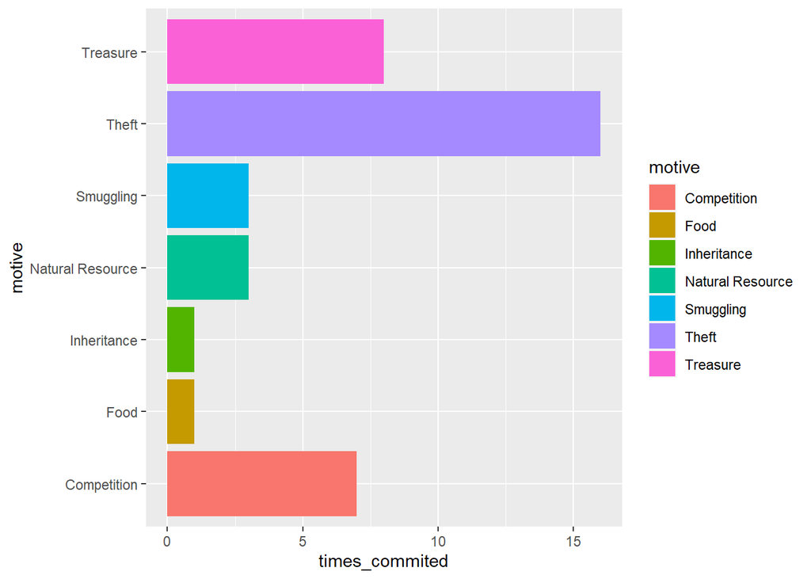

```r
ggplot(prof, aes(x = motive, y = times_commited, fill = motive)) +
 geom_col() +
  coord_flip()
```

#### This bar graph shows the amount of episodes that have certain ratings and we found out that most of the episodes in scooby doo have a rating on imdb between 7 - 8, with some outliers on both sides.

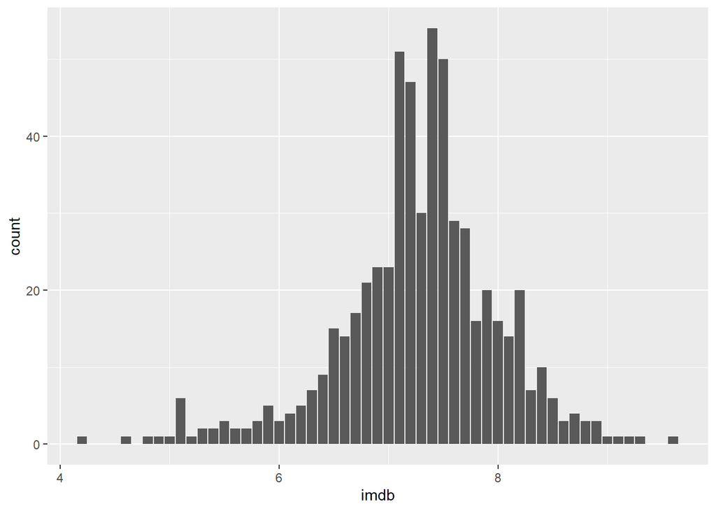

```r
scoobydoo %>%
  mutate(imdb = as.numeric(imdb)) %>%
  filter(!is.na(imdb)) %>%
  ggplot() +
    geom_bar(aes(x = imdb))
```

#### What we did was try to find out the mean rating of scooby doo episodes based on the television networks. What we found out was that cartoon network and cbs had the highest mean episode ratings.

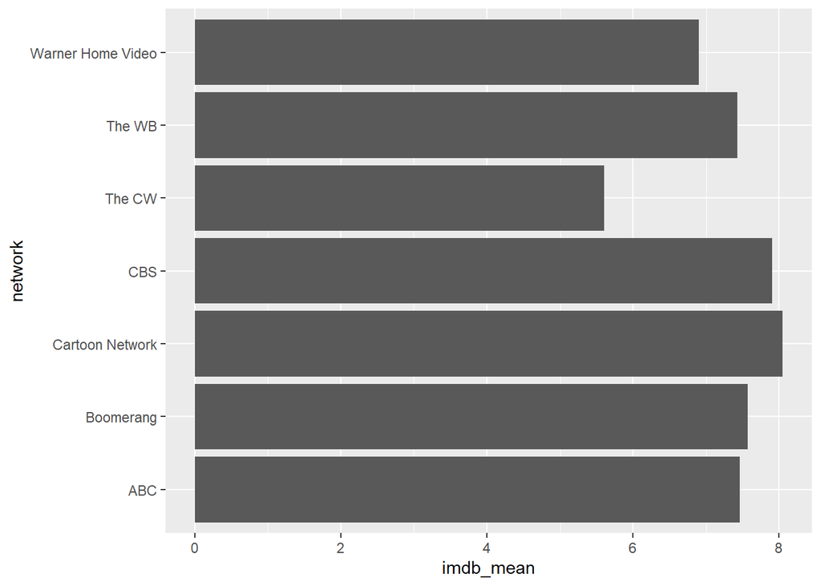

```r
scoobydoo %>%
  filter(format == "TV Series") %>%
  group_by(network) %>%
  summarise(imdb_mean = mean(as.numeric(imdb),na.rm = TRUE)) %>%
ggplot() +
  geom_col(aes(x = network,y = imdb_mean)) +
  coord_flip()
```

```
## Warning in mean(as.numeric(imdb), na.rm = TRUE): NAs introduced by coercion
```

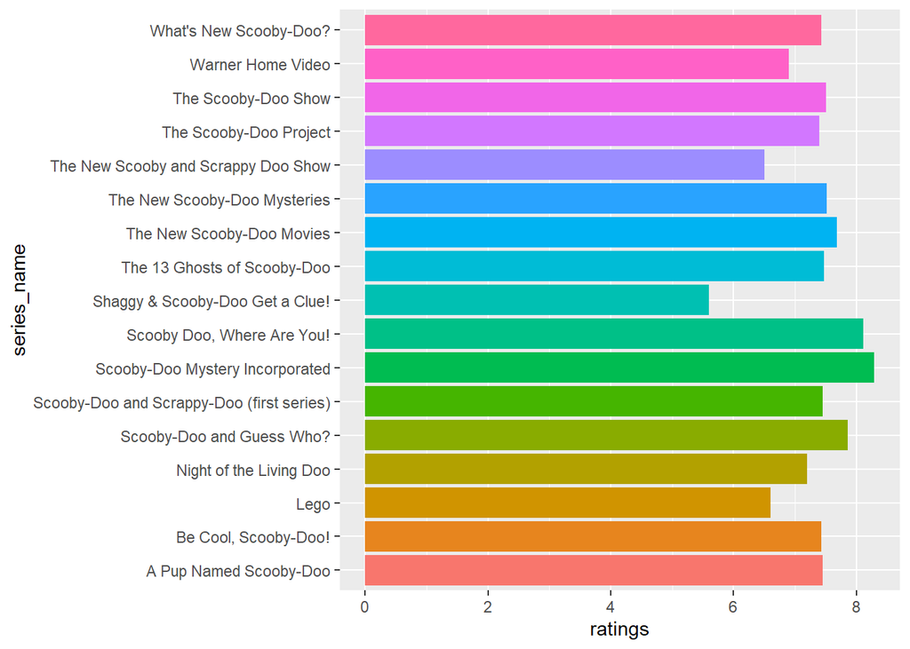

```r
  scoobydoo %>%
  filter(format == "TV Series") %>%
  group_by(series_name) %>%
  summarise(ratings = mean(as.numeric(imdb),na.rm = TRUE)) %>%
ggplot() +
  geom_col(aes(x = series_name,y = ratings, fill = series_name)) +
  coord_flip() + theme(legend.position = "None")
```

#### The visualization here shows how the audience was engaged for each network that a series of scooby-doo with the highest being of course Warner which owns the franchise, while the lowest being the CW a network that is mainly for adults

```
## Warning in mean(as.numeric(engagement), na.rm = TRUE): NAs introduced by
## coercion
```

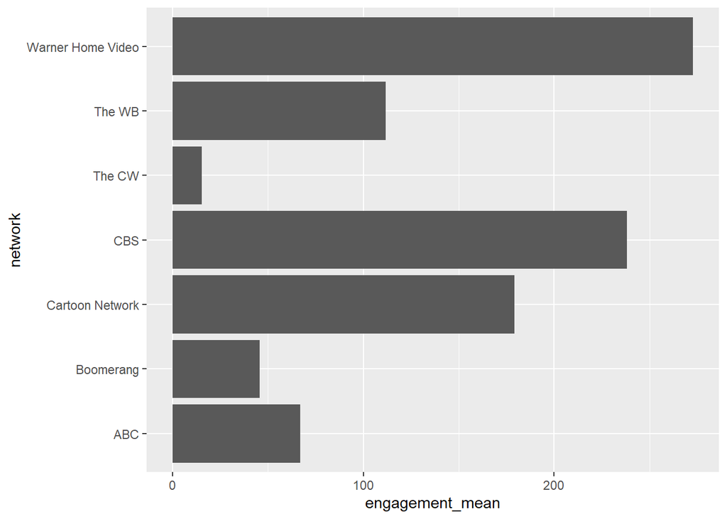

```r
scoobydoo %>%
  filter(format == "TV Series") %>%
  group_by(network) %>%
  summarise(engagement_mean = mean(as.numeric(engagement),na.rm = TRUE)) %>%
ggplot() +
  geom_col(aes(x = network,y = engagement_mean)) +
  coord_flip()
```

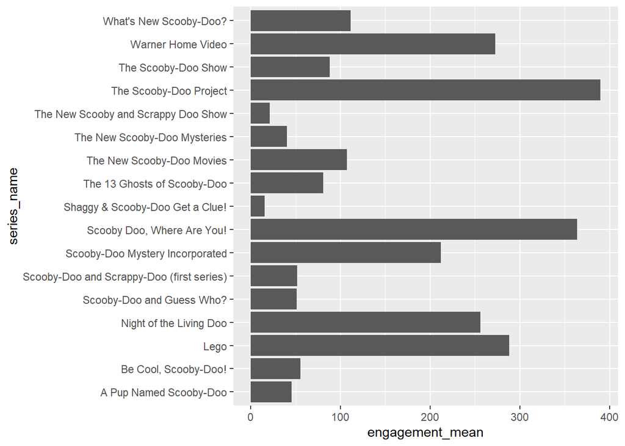

```r
scoobydoo %>%
  filter(format == "TV Series") %>%
  group_by(series_name) %>%
  summarise(engagement_mean = mean(as.numeric(engagement),na.rm = TRUE)) %>%
ggplot() +
  geom_col(aes(x = series_name,y = engagement_mean)) +
  coord_flip()
```

#### The visualization holds the amount of criminals in the Scooby Doo over the years. The code, due to the expansive amount of series, was enlarged to have a height of four and a width of seven. Ignoring the negative continuity of the Scooby Doo shows, if the goal of the gang was to reduce and maybe even achieve the lack of monster based attacks on the places they explore, the endeavor seems to be fruitless as the dots on the graph remain stagnant despite all of their hard work. An observation of a sudden jump in criminals teaming up together can be seen in recent years in all actuality.

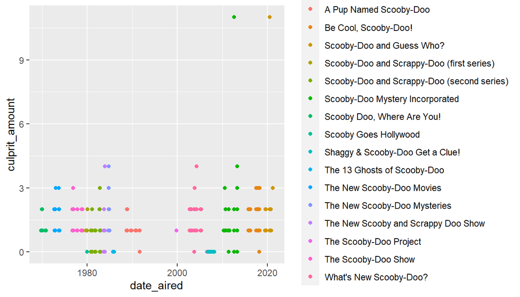

```r
scoobydoo %>%
  filter(str_detect(string = series_name, pattern = "Scooby")) %>%
  ggplot() +
  geom_point(aes(x = date_aired, y = culprit_amount, color = series_name))
```

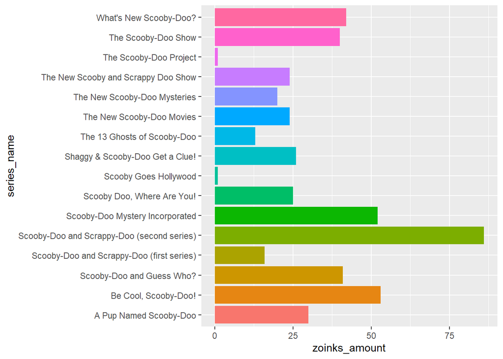

```r
DS <- scoobydoo %>%
  filter(str_detect(string = series_name, pattern = "Scooby")) %>%
  select(series_name, zoinks) %>%
  group_by(series_name) %>%
  summarize(zoinks_amount = n())

ggplot(DS, aes(x = series_name, y = zoinks_amount, fill = series_name)) + geom_bar(stat = "identity") + coord_flip() +
  theme(legend.position = "None")
```

#### The visualization offers a in-depth look at the places where the most populous species in the series reside. To process the multiple values in the monster cells, the commands of `seperate()` and `pivot_longer()` to splice all of the monster values into separate columns. The created variable *monsterNum* helps with this process to iteratively create the needed columns. Urban locations often attract the most varieties of monsters in Scooby Doo lore, with Rural places in second place and Forest and Desert biomes tying with each other for third. This is indicative of the flexibility of Human-Populated areas to house real monsters.

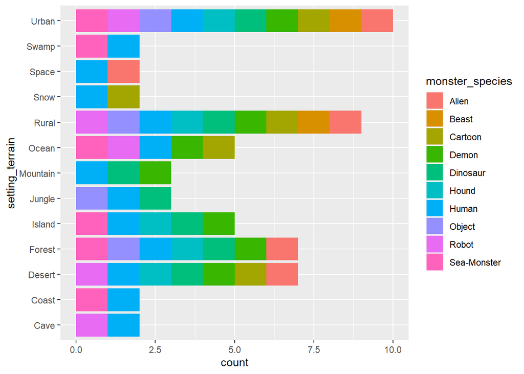

```r
monsterNum <- max(scoobydoo$monster_amount)

scoobydoo %>%
  select(index, monster_species, setting_terrain) %>%
  separate(monster_species, sep = ",", into = paste0("monsters_species", 1:monsterNum)) %>%
  pivot_longer(cols = starts_with("monsters_species"), names_to = "monsterNum", values_to = "monster_species") %>%
  filter(!is.na(monster_species)) %>%
  group_by(monster_species, setting_terrain) %>%
  count(monster_species) %>%
  arrange(desc(n)) %>%
  filter(monster_species != "NULL") %>%
  filter(monster_species %in% c("Human", "Alien", "Demon", "Cartoon", "Hound", "Dinosaur", "Robot", "Sea-Monster", "Beast", "Object")) %>%
  ggplot() +
  geom_bar(aes(x = setting_terrain, fill = monster_species)) +
  coord_flip()
```

#### Leading into the next extra tidbit about monsters with respect to their habitats, the visualization was altered to show the actual amount that resides in each of the biomes. It achieve this, the section starting from `group_by` to `arrange` have been deleted. The leading species in appearance is Human, as the primary premise of the show is about un-masking the fake beasts of the night. However, the gang has went up against real monsters, and an Urban setting remains at the number one spot with the most types of monsters and the most dense amount of monsters in the whole Scooby Doo Lore.

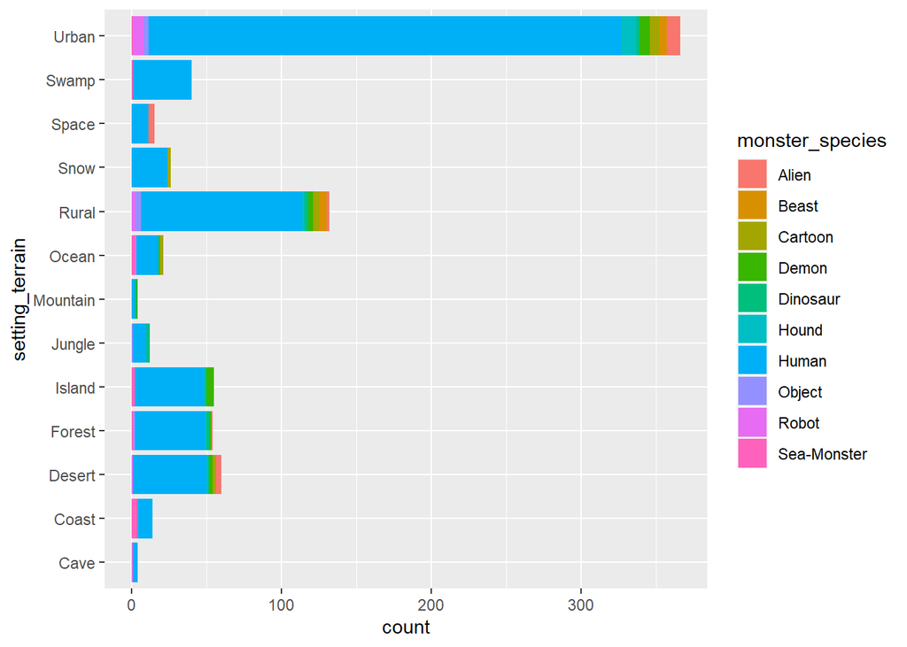

```r
monsterNum <- max(scoobydoo$monster_amount)

scoobydoo %>%
  select(index, monster_species, setting_terrain) %>%
  separate(monster_species, sep = ",", into = paste0("monsters_species", 1:monsterNum)) %>%
  pivot_longer(cols = starts_with("monsters_species"), names_to = "monsterNum", values_to = "monster_species") %>%
  filter(!is.na(monster_species)) %>%
  filter(monster_species != "NULL") %>%
  filter(monster_species %in% c("Human", "Alien", "Demon", "Cartoon", "Hound", "Dinosaur", "Robot", "Sea-Monster", "Beast", "Object")) %>%
  ggplot() +
  geom_bar(aes(x = setting_terrain, fill = monster_species)) +
  coord_flip()
```

#### This data adds a new column that are just the special characters that appear in scooby doo episodes, the characters being: batman, Scooby Dum, Scrappy, The Hex Girls, and Blue Falcon. I manage to find out how many episodes a special character had shown up in the series, which is 225 episodes!

```r
batsdt <- scoobydoo %>%
  filter(str_detect(string = batman, pattern = "TRUE")) %>%
  mutate(special = "batsdt")
scoobydum <- scoobydoo %>%
  filter(str_detect(string = scooby_dum, pattern = "TRUE" ))%>%
  mutate(special = "scoobydum")
scrappy <- scoobydoo %>%
  filter(str_detect(string = scrappy_doo, pattern = "TRUE")) %>%
  mutate(special = "scrappy")
hex <- scoobydoo %>%
  filter(str_detect(string = hex_girls, pattern = "TRUE")) %>%
  mutate(special = "hex")
falcon <- scoobydoo %>%
  filter(str_detect(string = blue_falcon, pattern = "TRUE")) %>%
  mutate(special = "falcon")
rbind(batsdt, scoobydum, scrappy, hex, falcon)
```

| index | series_name | network | season | title | imdb | engagement | date_aired | run_time | format | monster_name | monster_gender | monster_type | monster_subtype | monster_species | monster_real | monster_amount | caught_fred | caught_daphnie | caught_velma | caught_shaggy | caught_scooby | captured_fred | captured_daphnie | captured_velma | captured_shaggy | captured_scooby | unmask_fred | unmask_daphnie | unmask_velma | … |
| --- | --- | --- | --- | --- | --- | --- | --- | --- | --- | --- | --- | --- | --- | --- | --- | --- | --- | --- | --- | --- | --- | --- | --- | --- | --- | --- | --- | --- | --- | --- |
| 27 | The New Scooby-Doo Movies | CBS | 1 | The Dynamic Scooby-Doo Affair | 7.8 | 232 | 1972-09-16 | 41 | TV Series | Hooded Man,Skeletons | Male,Male | Disguised,Skeleton | Hooded,Humaniod | Human,Human | FALSE | 2 | FALSE | FALSE | FALSE | FALSE | FALSE | FALSE | FALSE | FALSE | FALSE | FALSE | FALSE | FALSE | FALSE | … |
| 40 | The New Scooby-Doo Movies | CBS | 1 | The Caped Crusader Caper | 7.2 | 183 | 1972-12-16 | 43 | TV Series | Dryad,Troll | Male,Male | Mythical,Mythical | Tree,Humanoid | Dryad,Troll | FALSE | 2 | FALSE | FALSE | FALSE | TRUE | FALSE | TRUE | FALSE | FALSE | FALSE | FALSE | FALSE | FALSE | FALSE | … |
| 540 | Warner Home Video | Cartoon Network | Movie | Batman: The Brave and the Bold: Bat-Mite Presents: Batman's Strangest Cases! | 6.6 | 1698 | 2018-01-09 | 75 | Movie | Crimson Cloak | Male | Ghost | Phantom | Human | FALSE | 1 | TRUE | FALSE | FALSE | FALSE | FALSE | FALSE | FALSE | FALSE | FALSE | FALSE | FALSE | FALSE | TRUE | … |
| 571 | Scooby-Doo and Guess Who? | Boomerang | 1 | What a Night, for a Dark Knight | 8.7 | 84 | 2019-09-19 | 22 | TV Series | Man-Bat | Male | Animal | Humanoid | Bat | FALSE | 1 | FALSE | FALSE | FALSE | TRUE | TRUE | TRUE | TRUE | TRUE | TRUE | TRUE | FALSE | FALSE | FALSE | … |
| 54 | The Scooby-Doo Show | ABC | 1 | The Gruesome Game of the Gator Ghoul | 7.5 | 95 | 1976-09-25 | 24 | TV Series | Ghost of Gator Ghoul | Male | Ghost | Amphibian | Alligator | FALSE | 1 | TRUE | FALSE | FALSE | FALSE | FALSE | FALSE | FALSE | FALSE | FALSE | FALSE | FALSE | FALSE | FALSE | … |
| 56 | The Scooby-Doo Show | ABC | 1 | The Headless Horseman of Halloween | 8 | 127 | 1976-10-09 | 24 | TV Series | Headless Horseman | Male | Ghost | Headless | Human | FALSE | 1 | FALSE | FALSE | FALSE | FALSE | FALSE | FALSE | FALSE | FALSE | FALSE | FALSE | FALSE | FALSE | FALSE | … |
| 71 | Laff-a-Lympics | ABC | 1 | Tokyo, Japan | 6.9 | 25 | 1977-09-10 | 12 | TV Series (segmented) | NULL | NULL | NULL | NULL | NULL | NULL | 0 | NULL | NULL | NULL | FALSE | FALSE | NULL | NULL | NULL | FALSE | FALSE | NULL | NULL | NULL | … |
| 72 | The Scooby-Doo Show | ABC | 2 | Vampire Bats and Scaredy Cats | 8.2 | 104 | 1977-09-17 | 24 | TV Series | Gramps the Vamp | Male | Undead | Vampire | Human | FALSE | 1 | FALSE | FALSE | FALSE | TRUE | FALSE | FALSE | FALSE | FALSE | FALSE | FALSE | TRUE | FALSE | FALSE | … |
| 73 | Laff-a-Lympics | ABC | 1 | Acapulco | 6.3 | 23 | 1977-09-17 | 12 | TV Series (segmented) | NULL | NULL | NULL | NULL | NULL | NULL | 0 | NULL | NULL | NULL | NULL | FALSE | NULL | NULL | NULL | NULL | FALSE | NULL | NULL | NULL | … |
| 76 | Laff-a-Lympics | ABC | 1 | Florida | 7.1 | 22 | 1977-09-24 | 12 | TV Series (segmented) | NULL | NULL | NULL | NULL | NULL | NULL | 0 | NULL | NULL | NULL | NULL | NULL | NULL | NULL | NULL | NULL | NULL | NULL | NULL | NULL | … |

[output cut: 215 more lines]

```r
scoobydoo %>%
  filter(if_it_wasnt_for != "NULL") %>%
  select(if_it_wasnt_for, culprit_name) %>%
  arrange(desc(nchar(if_it_wasnt_for))) %>%
  head(1)
```

| if_it_wasnt_for | culprit_name |
| --- | --- |
| that meddling lawyer didn't discover that suprise envelope with evidence that proved who the toxic mutant really was | Dayton Knight |

```r
scoobydoo %>%
  filter(and_that != "NULL") %>%
  select(and_that, culprit_name) %>%
  arrange(desc(nchar(and_that))) %>%
  head(1)
```

| and_that | culprit_name |
| --- | --- |
| and famous singer/award-winning, multi-platinum, alternate pop maverick, Halsey! | Poetry Slam Promoter |